# Queue (Antrian)

Bayangkan Queue seperti orang-orang yang berdiri berbaris di supermarket.

Orang pertama yang mengantre juga merupakan orang pertama yang dapat membayar dan meninggalkan supermarket.

Operasi dasar yang dapat kita lakukan pada queu adalah:

- Enqueue: Menambahkan elemen baru ke dalam antrian.
- Dequeue: Menghapus dan mengembalikan elemen pertama (terdepan) dari antrian.
- Peek: Mengembalikan elemen pertama dalam antrian.
- isEmpty: Memeriksa apakah antrian kosong.
- Ukuran: Menemukan jumlah elemen dalam antrian.

Antrian dapat diimplementasikan dengan menggunakan array atau linked list.

Antrian dapat digunakan untuk mengimplementasikan penjadwalan pekerjaan untuk printer kantor, pemrosesan pesanan untuk tiket elektronik, atau untuk membuat algoritma pencarian breadth-first dalam grafik.

Antrian sering disebut bersamaan dengan Tumpukan, yang merupakan struktur data serupa yang dijelaskan pada halaman sebelumnya.

## Queue Implementation using Python Lists

Untuk daftar (dan array) Python, sebuah Queue dapat terlihat dan berperilaku seperti ini:

x = [5, 6, 2, 9, 3, 8, 4, 2]

Karena list Python memiliki dukungan yang baik untuk fungsionalitas yang dibutuhkan untuk mengimplementasikan antrian, kita mulai dengan membuat antrian dan melakukan operasi antrian hanya dengan beberapa baris kode:

Contoh

Menggunakan list Python sebagai antrian:

```python
queue = []

# Enqueue
queue.append('A')
queue.append('B')
queue.append('C')
print("Queue: ", queue)

# Peek
frontElement = queue[0]
print("Peek: ", frontElement)

# Dequeue
poppedElement = queue.pop(0)
print("Dequeue: ", poppedElement)

print("Queue after Dequeue: ", queue)

# isEmpty
isEmpty = not bool(queue)
print("isEmpty: ", isEmpty)

# Size
print("Size: ", len(queue))
```

```
Queue:  ['A', 'B', 'C']
Peek:  A
Dequeue:  A
Queue after Dequeue:  ['B', 'C']
isEmpty:  False
Size:  2
```

**Catatan:** Meskipun menggunakan list itu sederhana, menghapus elemen dari awal (operasi dequeue) memerlukan pergeseran semua elemen yang tersisa, sehingga kurang efisien untuk antrian yang besar.

Mengimplementasikan Kelas Antrian

Berikut implementasi lengkap dari kelas Queue:

Contoh

Menggunakan kelas Python sebagai antrian:

```python
class Queue:
  def __init__(self):
    self.queue = []

  def enqueue(self, element):
    self.queue.append(element)

  def dequeue(self):
    if self.isEmpty():
      return "Queue is empty"
    return self.queue.pop(0)

  def peek(self):
    if self.isEmpty():
      return "Queue is empty"
    return self.queue[0]

  def isEmpty(self):
    return len(self.queue) == 0

  def size(self):
    return len(self.queue)

# Create a queue
myQueue = Queue()

myQueue.enqueue('A')
myQueue.enqueue('B')
myQueue.enqueue('C')

print("Queue: ", myQueue.queue)
print("Peek: ", myQueue.peek())
print("Dequeue: ", myQueue.dequeue())
print("Queue after Dequeue: ", myQueue.queue)
print("isEmpty: ", myQueue.isEmpty())
print("Size: ", myQueue.size())
```

```
Queue:  ['A', 'B', 'C']
Peek:  A
Dequeue:  A
Queue after Dequeue:  ['B', 'C']
isEmpty:  False
Size:  2
```

## Queue Implementation using Linked Lists

Sebuah linked list terdiri dari node yang berisi data tertentu, dan sebuah pointer ke node berikutnya.

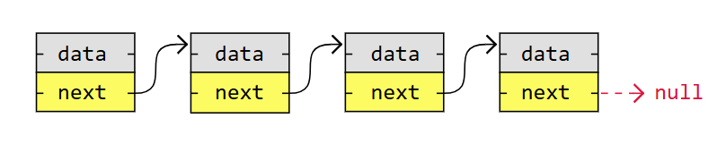

Salah satu keuntungan besar menggunakan linked list adalah node disimpan di mana pun ada ruang kosong di memori, node tidak perlu disimpan berdekatan satu sama lain seperti elemen yang disimpan dalam array. Keuntungan lain dari linked list adalah ketika menambahkan atau menghapus node, node lain dalam list tidak perlu digeser.

Untuk lebih memahami manfaat menggunakan array atau linked list untuk mengimplementasikan antrian, Anda sebaiknya memeriksa halaman ini yang menjelaskan bagaimana array dan linked list disimpan dalam memori.

Beginilah cara mengimplementasikan antrian menggunakan linked list.

Contoh

Membuat Antrian menggunakan Daftar Tertaut:

```python
class Node:
  def __init__(self, data):
    self.data = data
    self.next = None

class Queue:
  def __init__(self):
    self.front = None
    self.rear = None
    self.length = 0

  def enqueue(self, element):
    new_node = Node(element)
    if self.rear is None:
      self.front = self.rear = new_node
      self.length += 1
      return
    self.rear.next = new_node
    self.rear = new_node
    self.length += 1

  def dequeue(self):
    if self.isEmpty():
      return "Queue is empty"
    temp = self.front
    self.front = temp.next
    self.length -= 1
    if self.front is None:
      self.rear = None
    return temp.data

  def peek(self):
    if self.isEmpty():
      return "Queue is empty"
    return self.front.data

  def isEmpty(self):
    return self.length == 0

  def size(self):
    return self.length

  def printQueue(self):
    temp = self.front
    while temp:
      print(temp.data, end=" -> ")
      temp = temp.next
    print()

# Create a queue
myQueue = Queue()

myQueue.enqueue('A')
myQueue.enqueue('B')
myQueue.enqueue('C')

print("Queue: ", end="")
myQueue.printQueue()
print("Peek: ", myQueue.peek())
print("Dequeue: ", myQueue.dequeue())
print("Queue after Dequeue: ", end="")
myQueue.printQueue()
print("isEmpty: ", myQueue.isEmpty())
print("Size: ", myQueue.size())
```

```
Queue: A -> B -> C ->
Peek:  A
Dequeue:  A
Queue after Dequeue: B -> C ->
isEmpty:  False
Size:  2
```

Alasan menggunakan linked list untuk mengimplementasikan antrian:

**Ukuran dinamis**: Antrian dapat bertambah besar dan kecil secara dinamis, tidak seperti pada array.

Alasan mengapa linked list **tidak digunakan untuk mengimplementasikan antrian**:

**Memori tambahan**: Setiap elemen antrian harus berisi alamat ke elemen berikutnya (node daftar tertaut berikutnya).

**Keterbacaan**: Kode ini mungkin lebih sulit dibaca dan ditulis bagi sebagian orang karena lebih panjang dan lebih kompleks.

## Soal-soal

1. Simulasi antrian pasien.

```python
def antrian_pasien():
    queue = []

    queue.append("Pasien A")
    queue.append("Pasien B")
    queue.append("Pasien C")

    while queue:
        print(queue.pop(0), "sedang dilayani")

antrian_pasien()
```

```
Pasien A sedang dilayani
Pasien B sedang dilayani
Pasien C sedang dilayani
```

2. Jelaskan FIFO dan perbedaan dengan stack.

Queue:

- FIFO
- enqueue & dequeue
- depan-belakang

Stack :

- LIFO
- push & pop
- satu sisi (atas)
3. Tampilkan isi queue tanpa menghapus.

```python
q = [10, 20, 30]

for item in q:
    print(item)
```

```
10
20
30
```

4. Queue dengan batas maksimum.

```python
class Queue:
    def __init__(self, max_size):
        self.data = []
        self.max_size = max_size

    def enqueue(self, item):
        if len(self.data) == self.max_size:
            print("Overflow!")
        else:
            self.data.append(item)

    def dequeue(self):
        if not self.data:
            print("Underflow!")
        else:
            return self.data.pop(0)

q = Queue(3)
q.enqueue(1)
q.enqueue(2)
q.enqueue(3)
q.enqueue(4)
```

```
Overflow!
```

5. Tuliskan pseudocode enqueue dan dequeue.

Enqueue:

ENQUEUE(queue, data):

```
tambahkan data ke belakang queue
```

Dequeue:

DEQUEUE(queue):

```
jika queue kosong:
    tampilkan "kosong"
jika tidak:
    ambil dan hapus elemen depan
```